# EXPLORATORY DATA ANALYSIS

#### 5. How can you add, change or remove features to get more out of your data?

Now let us look at the age variable, I would like to say that it is a category variable but it has too many categories. Let up plot this to prove it.

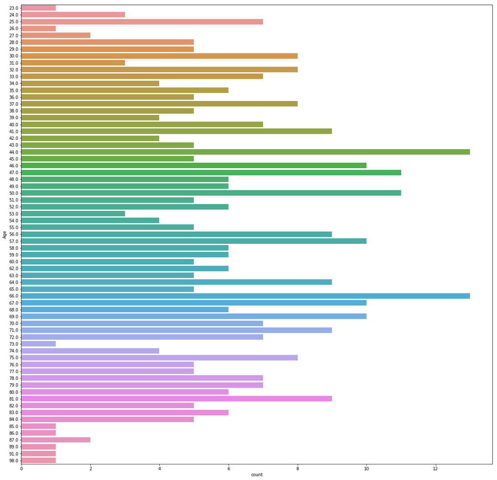

```python
fig = plt.figure(figsize=(20,20))
sns.countplot(y=df_bin['Age'], data=df_bin);
```

These are so many categories to analyse. Some categorical variables such as this can be put into groups. Since we are dealing with age, let us try and put the clients into age groups. We can do this by putting them into age groups of 10 or 5 years. For this analysis let us do so for 10 years. So we will start with age group 20-29 then 30-39 and so on.

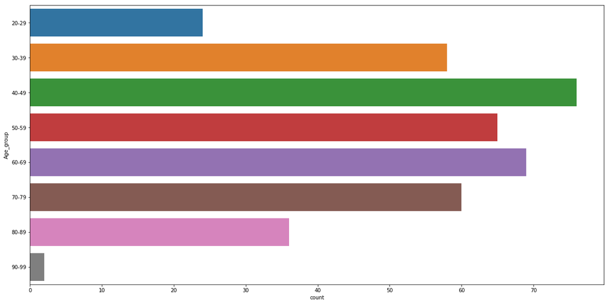

```python
df_bin['Age_group'] = pd.cut(df_bin['Age'], [20, 29, 39,49, 59,69,79,89,99],
                   labels=['20-29', '30-39', '40-49','50-59','60-69','70-79',
                           '80-89','90-99'])

fig = plt.figure(figsize=(20,10))
sns.countplot(y=df_bin['Age_group'], data=df_bin);
```

Great! Now the categories above make more sense and can be used for analysis. The Bank seems to have clients mostly from the ages of 30 to 79. We can do a comparison with the other variables such as number of cards in each age group or even gender but you can do that for practise :)...

We will do the analysis of age groups with Balance and Income.

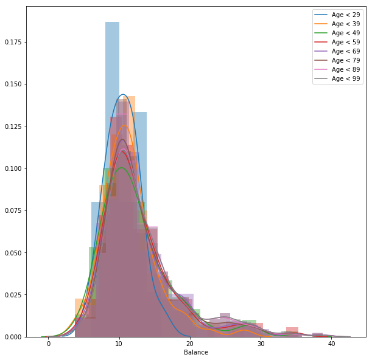

```python
fig = plt.figure(figsize=(10, 10))
sns.distplot(df_bin.loc[df_bin['Age'] < 29 ]['Balance'], kde_kws={'label': 'Age < 29'});
sns.distplot(df_bin.loc[df_bin['Age'] < 39 ]['Balance'], kde_kws={'label': 'Age < 39'});
sns.distplot(df_bin.loc[df_bin['Age'] < 49 ]['Balance'], kde_kws={'label': 'Age < 49'});
sns.distplot(df_bin.loc[df_bin['Age'] < 59 ]['Balance'], kde_kws={'label': 'Age < 59'});
sns.distplot(df_bin.loc[df_bin['Age'] < 69 ]['Balance'], kde_kws={'label': 'Age < 69'});
sns.distplot(df_bin.loc[df_bin['Age'] < 79 ]['Balance'], kde_kws={'label': 'Age < 79'});
sns.distplot(df_bin.loc[df_bin['Age'] < 89 ]['Balance'], kde_kws={'label': 'Age < 89'});
sns.distplot(df_bin.loc[df_bin['Age'] < 99 ]['Balance'], kde_kws={'label': 'Age < 99'});
```

| Age_group | 0 |
| --- | --- |
| 20-29 | 24 |
| 30-39 | 58 |
| 40-49 | 76 |
| 50-59 | 65 |
| 60-69 | 69 |

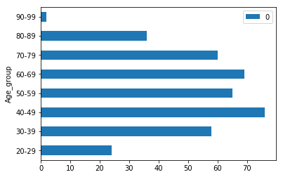

```python
ga = pd.DataFrame(df_bin.groupby('Age_group').size())
ga.plot(kind='barh')
ga.head()
```

#### Ultimately, there’s no limit to the number of experiments one can perform in the EDA process – it completely depends on what you’re analyzing, as well as the knowledge of packages such as Pandas and matplotlib our job becomes easier.

## Compulsory Task

Use the Titanic dataset provided and Go wild with your analysis. Provide an indepth EDA on the data set be creative.

```python
#we gonna start by reading into our data and display the head to have an idea of what we're dealing with
titanic = pd.read_csv(r"C:\Users\byamu\OneDrive\Documents\booky\Task 15\train.csv")
titanic.head()
```

|  | PassengerId | Survived | Pclass | Name | Sex | Age | SibSp | Parch | Ticket | Fare | Cabin | Embarked |
| --- | --- | --- | --- | --- | --- | --- | --- | --- | --- | --- | --- | --- |
| 0 | 1 | 0 | 3 | Braund, Mr. Owen Harris | male | 22.0 | 1 | 0 | A/5 21171 | 7.2500 | NaN | S |
| 1 | 2 | 1 | 1 | Cumings, Mrs. John Bradley (Florence Briggs Th... | female | 38.0 | 1 | 0 | PC 17599 | 71.2833 | C85 | C |
| 2 | 3 | 1 | 3 | Heikkinen, Miss. Laina | female | 26.0 | 0 | 0 | STON/O2. 3101282 | 7.9250 | NaN | S |
| 3 | 4 | 1 | 1 | Futrelle, Mrs. Jacques Heath (Lily May Peel) | female | 35.0 | 1 | 0 | 113803 | 53.1000 | C123 | S |
| 4 | 5 | 0 | 3 | Allen, Mr. William Henry | male | 35.0 | 0 | 0 | 373450 | 8.0500 | NaN | S |

```python
titanic.dtypes
```

```
PassengerId      int64
Survived         int64
Pclass           int64
Name            object
Sex             object
Age            float64
SibSp            int64
Parch            int64
Ticket          object
Fare           float64
Cabin           object
Embarked        object
dtype: object
```

```python
#next we gonna try and get the basic info of our df by calling the describ method on it
titanic.describe()

#but we gonna get into details only later
```

|  | PassengerId | Survived | Pclass | Age | SibSp | Parch | Fare |
| --- | --- | --- | --- | --- | --- | --- | --- |
| count | 891.000000 | 891.000000 | 891.000000 | 714.000000 | 891.000000 | 891.000000 | 891.000000 |
| mean | 446.000000 | 0.383838 | 2.308642 | 29.699118 | 0.523008 | 0.381594 | 32.204208 |
| std | 257.353842 | 0.486592 | 0.836071 | 14.526497 | 1.102743 | 0.806057 | 49.693429 |
| min | 1.000000 | 0.000000 | 1.000000 | 0.420000 | 0.000000 | 0.000000 | 0.000000 |
| 25% | 223.500000 | 0.000000 | 2.000000 | 20.125000 | 0.000000 | 0.000000 | 7.910400 |
| 50% | 446.000000 | 0.000000 | 3.000000 | 28.000000 | 0.000000 | 0.000000 | 14.454200 |
| 75% | 668.500000 | 1.000000 | 3.000000 | 38.000000 | 1.000000 | 0.000000 | 31.000000 |
| max | 891.000000 | 1.000000 | 3.000000 | 80.000000 | 8.000000 | 6.000000 | 512.329200 |

```python
titanic.shape
```

[output not shown]

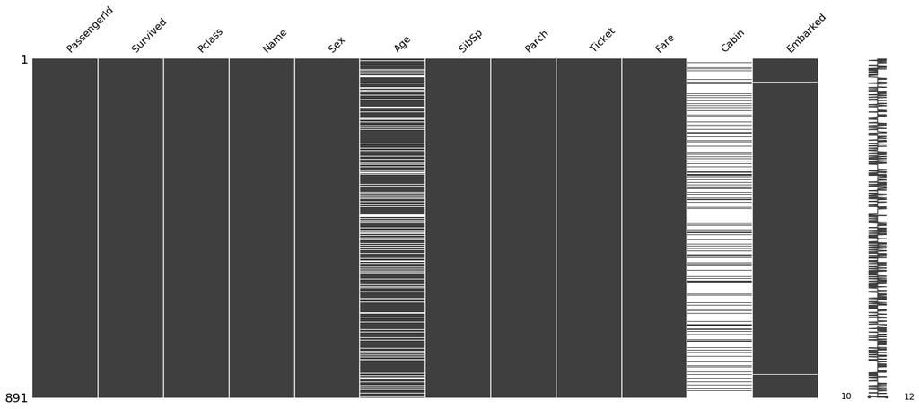

```python
missingno.matrix(titanic, )
```

```python
#it looks the majority of our columns are clean and that we only have missing values in three columns
#we can also prove that by count the missing values
titanic.isnull().sum()
```

```
PassengerId      0
Survived         0
Pclass           0
Name             0
Sex              0
Age            177
SibSp            0
Parch            0
Ticket           0
Fare             0
Cabin          687
Embarked         2
dtype: int64
```

```python
np.product(titanic.shape)
```

```
10692
```

```python
titanic.isnull().sum().sum()
```

```
866
```

```python
#if we do the math it almost the 10th of a the data set that is missing
866/10692*100
```

```
8.099513655069211
```

FROM HERE WE CAN DECIDE WHAT TO DO WITH THOSE MISSING DATA

FROM MY POINT OF VIEW 'Cabin' IS ALMOST EMPTY. THE TOTAL NUMBER OF ROWS IS 891 AND 687 IS MISSING SO WE WILL DROP THIS ROW AND THE 2 MISSING COLON IN 'Embarked'

ABOUT THE AGE COLUMN :) I'M GONNA TAKE A CHANCE AND WORK WITH IT AS IT IS.

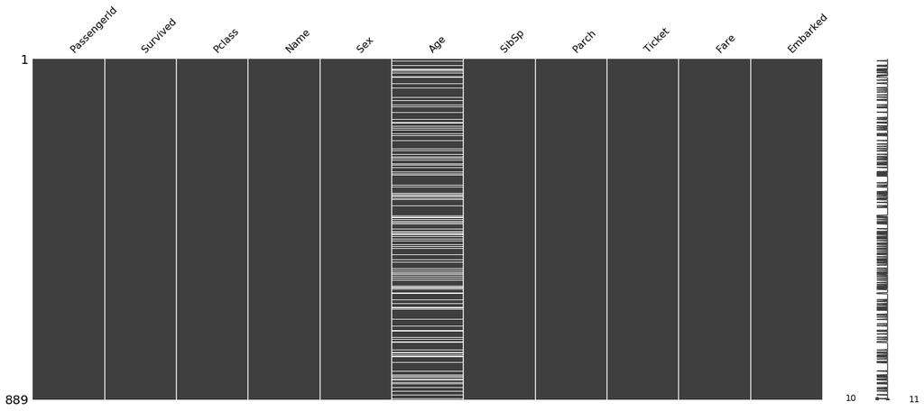

```python
titanic.drop('Cabin', axis=1, inplace=True)      #over here we drop the cabin column on the and save the change by passing the inplace argument
titanic.dropna(subset=['Embarked'], how = 'any', inplace=True) #and here we are droping all the where any of the embarked row has a missing value

### cool
missingno.matrix(titanic)
```

# WHAT ARE WE LOOKING FOR ANYWAY?

### THE GREATEST VARIABLE IN THIS DATASET IS **SURVIVED**

I THINK THIS VARIABLE IS IMPORTANT BECAUSE LIFE IS INVOLVED  
SO WE MIGHT WANT TO ANSWER VERY SIMPLE QUESTIONS SUCH AS:

## OK LET THE DATA TELL THE STORY(AS IS IT WAS)

- **WHO SURVIVED?**

```python
titanic.groupby(titanic.Embarked).Survived.value_counts(normalize=True)
```

```
Embarked  Survived
C         1           0.553571
          0           0.446429
Q         0           0.610390
          1           0.389610
S         0           0.663043
          1           0.336957
Name: Survived, dtype: float64
```

```python
titanic.Survived.value_counts()
```

[output not shown]

SO WE SEE THAT THE NUMBER OF SURVIVORS IS LOW COMPARE TO THOSE WHO COULDN'T MAKE IT  
with what we know now WE CAN TRY AND GET SOME INSIGHT. LIKE THEIR GENDER ETC

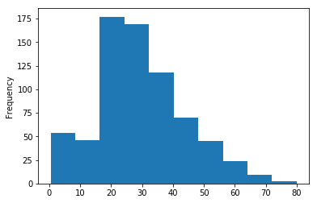

```python
titanic.Age.plot(kind='hist')#and we can see significant  amount of people between the age of 20 and 40
```

```python
titanic.Age.describe() #we know that we have a huge amount of missing rows in age column but we just gonna plot what we have for now.
```

[output not shown]

WE GOING TO GROUP THE AGE COLUMN INTO 6 CATEGORY

[Babies < Childrens < Teenagers < Young Adults < Middle-Aged Adults < Senior]

```python
#THIS IS GOING to facilitate the analysis

titanic['Age_Group'] = pd.cut(titanic.Age, (0,2,13,17,35,55,200), labels= ['Babies', 'Childrens', 'Teenagers', 'Young Adults', 'Middle-Aged Adults', 'Senior' ])
```

```python
titanic.Age_Group.unique()
```

```
[Young Adults, Middle-Aged Adults, NaN, Babies, Teenagers, Childrens, Senior]
Categories (6, object): [Babies < Childrens < Teenagers < Young Adults < Middle-Aged Adults < Senior]
```

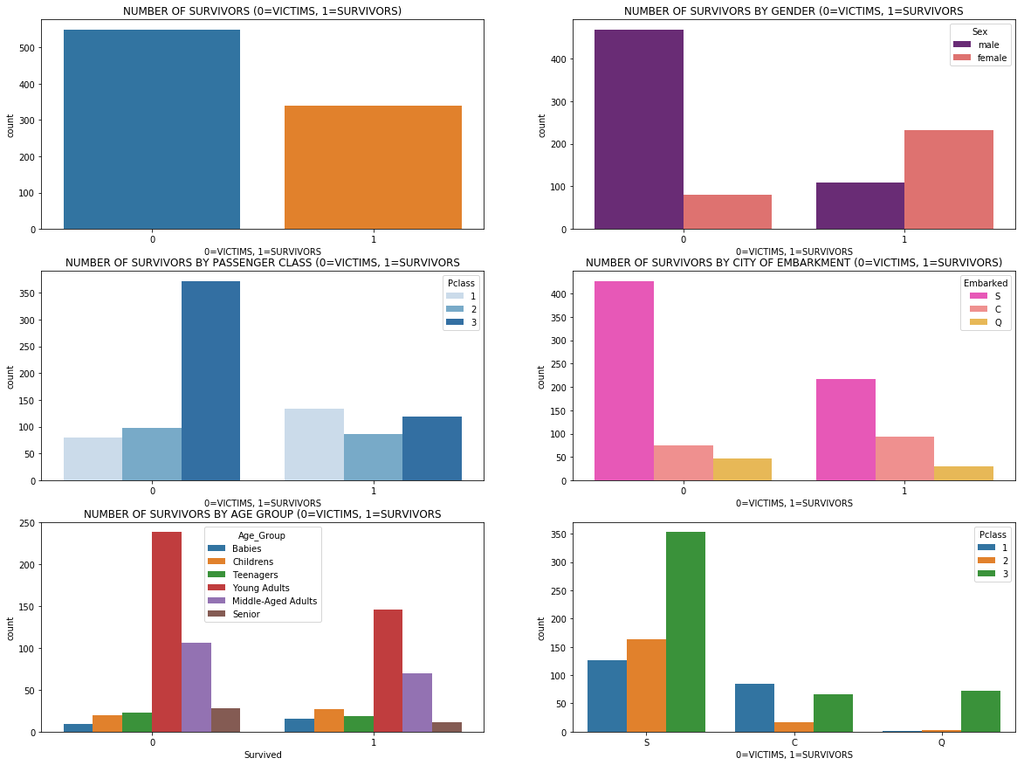

```python
fig = plt.figure(figsize=(20,15))   #WEW NEED A BIG CANVAS THAT CAN FIX ALL THE BASICS COUNTING SUMARY


#so the below block of code just use the same figure and i customize the position with the ax argument
ax = fig.add_subplot(321)
sns.countplot(x='Survived', data=titanic, ax=ax)
plt.title('NUMBER OF SURVIVORS (0=VICTIMS, 1=SURVIVORS)')
plt.xlabel('0=VICTIMS, 1=SURVIVORS')

ax2 = fig.add_subplot(322)
sns.countplot(titanic.Survived, hue=titanic.Sex,  palette='magma', ax=ax2)
plt.title('NUMBER OF SURVIVORS BY GENDER (0=VICTIMS, 1=SURVIVORS')
plt.xlabel('0=VICTIMS, 1=SURVIVORS')


ax3 = fig.add_subplot(323)
sns.countplot(x='Survived', data=titanic,  hue='Pclass', palette='Blues', ax=ax3)
plt.title('NUMBER OF SURVIVORS BY PASSENGER CLASS (0=VICTIMS, 1=SURVIVORS')
plt.xlabel('0=VICTIMS, 1=SURVIVORS')


ax4 = fig.add_subplot(324)
sns.countplot(x='Survived', data=titanic,  hue='Embarked', palette='spring', ax=ax4)
plt.title('NUMBER OF SURVIVORS BY CITY OF EMBARKMENT (0=VICTIMS, 1=SURVIVORS)')
plt.xlabel('0=VICTIMS, 1=SURVIVORS')


ax5 = fig.add_subplot(325)
sns.countplot(x='Survived', data=titanic, hue='Age_Group',ax=ax5)
plt.title('NUMBER OF SURVIVORS BY AGE GROUP (0=VICTIMS, 1=SURVIVORS')


ax5 = fig.add_subplot(326)
sns.countplot(x='Embarked', data=titanic, hue = 'Pclass')

plt.xlabel('0=VICTIMS, 1=SURVIVORS')
```

- ABOVE WE also HAVE A PICTURE OF SURVIVORS BY GENDER (SO JACK DECAPRIO WAS NOT THE ONLY LOVER WHO GAVE UP HIS LIFE FOR the sake HIS WIFE OR FEMALE PATNER)
- **WHERE DID THE MAJORITY OF PEOPLE COME FROM?**

```python
titanic.Embarked.value_counts()#
```

```
S    644
C    168
Q     77
Name: Embarked, dtype: int64
```

### Port of Embarkation

S = Southampton;644

C = Cherbourg;168

Q = Queenstown;77

southampton is 73% of the entire population on the boat. so if a graph like countplot shows them with highest number of death and survivors it does not mean that is true in terms of percentale.

- So then, how did the city of Embarkement affect the victims and the survivors?
  - first we see that the majority of people from Cherbourg survived and the rate of survivors is higher than the victims
  - now, why is it so? the below graphs shows the relationship between passenger class and survivors based on their port of embarkment. ##### for example the majority of people from Cherbourg port registered for First class and the their rate of victims is lower than the rate of Survivors compare to other Ports

```python
titanic.groupby('Embarked').Survived.value_counts(normalize= True).unstack()#so here we're normalizing the values
                                                                            #after counting in order to get the mean
```

| Survived Embarked | 0 | 1 |
| --- | --- | --- |
| C | 0.446429 | 0.553571 |
| Q | 0.610390 | 0.389610 |
| S | 0.663043 | 0.336957 |

AND THE BELOW GRAPHS WILL CONFIRM THAT.

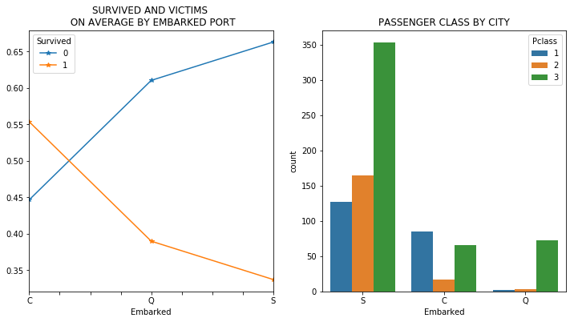

```python
fig = plt.figure(figsize=(12,6))


ax = fig.add_subplot(121)
titanic.groupby('Embarked').Survived.value_counts(normalize= True).unstack().plot(ax=ax, marker='*')
plt.title('SURVIVED AND VICTIMS \n ON AVERAGE BY EMBARKED PORT')

ax2 = fig.add_subplot(122)
sns.countplot(x='Embarked', data=titanic, hue='Pclass',ax=ax2)
plt.title('PASSENGER CLASS BY CITY')
```

- AND BELLOW WE SEE THAT THE THIRD CLASS HAS A HIGH RATE OF VICTIMS REGARDLESS OF THE PORT OF EMBARKMENT
- ON THE OTHER HAND, THE RATE OF SURVIVORS IS HIGH REGARDLESS OF THE PORT OF EMBARKMENT
- BUT THE SECOND CLASS IS A BIT SHY OR NEUTRAL. ONE CANNOT REALLY TELL THE STORY THERE(BUT WE CAN FIND OUT)

## SURVIVORS AND VICTIMS BY PASSENGER CLASS FOR EACH EMBARKED PORT

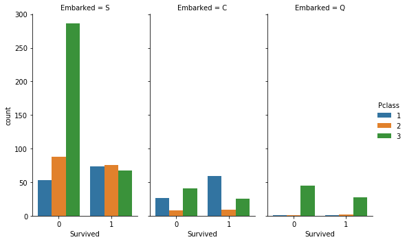

```python
sns.catplot(x='Survived', data= titanic, hue='Pclass',col='Embarked', kind='count',height=5, aspect = 0.5)
```

- SO THEN WHO IS THE BIGGEST LOSER BETWEEN THIS 3 PORTS? well the answer is pretty obvious

```python
titanic.groupby('Embarked').Pclass.value_counts()
```

```
Embarked  Pclass
C         1          85
          3          66
          2          17
Q         3          72
          2           3
          1           2
S         3         353
          2         164
          1         127
Name: Pclass, dtype: int64
```

BECAUSE C = Cherbourg registerd a lot of people in the first class their rate of survivors is high

on the other hand we S = Southampton as the biggest loser also related to the fact that they have registerd a lot of third class passengers

Q = Queenstown the same can be said of Queenstown

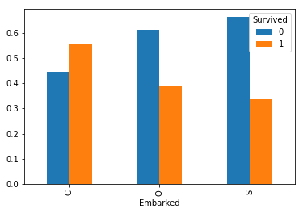

```python
titanic.groupby('Embarked').Survived.value_counts(normalize= True).unstack().plot(kind='bar')
```

### ALRIGHT NOW LET'S TALK A BIT ABOUT MONEY

https://www.quora.com/What-were-the-ticket-prices-to-board-the-Titanic

above is a source i used to get the tickets price range.

#### Costs of tickets to board the Titanic were:

- First Class (parlor suite) — £870/$4,350 ($50,000 today).
- First Class (berth)— £30/$150 ($1724 today).
- Second Class — £12/$60 ($690 today).
- Third Class — £3 to £8/$40 ($172 to $460 today).

```python
titanic.Fare.describe()
```

[output not shown]

- BUT WHAT DOES THE SUMMARY TELLS US?
  1. Min = 0.00 so there was people who did not pay to travel in this ship.
     - we gonna figure out who was this people and whether they survived or not (for free lol)
  2. Max = 512.32 the plot below shows that there was three induviduals who paid morethan 500.
     - Did they survived? Oh I bet they!

```python
titanic.loc[titanic.Fare >300]
```

[output not shown]

```python
titanic.loc[titanic.Fare < 1]
```

[output not shown]

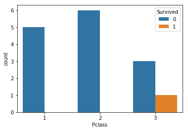

```python
a = titanic.loc[titanic.Fare < 1]


sns.countplot(x='Pclass', data=a, hue = 'Survived')
```

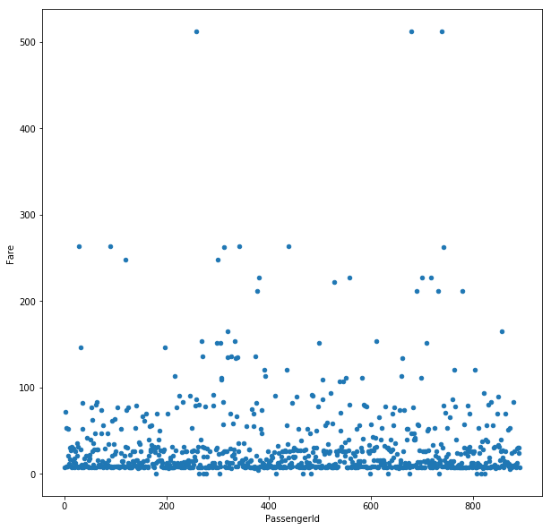

```python
titanic.plot.scatter(y='Fare', x='PassengerId', figsize=(10,10))
```

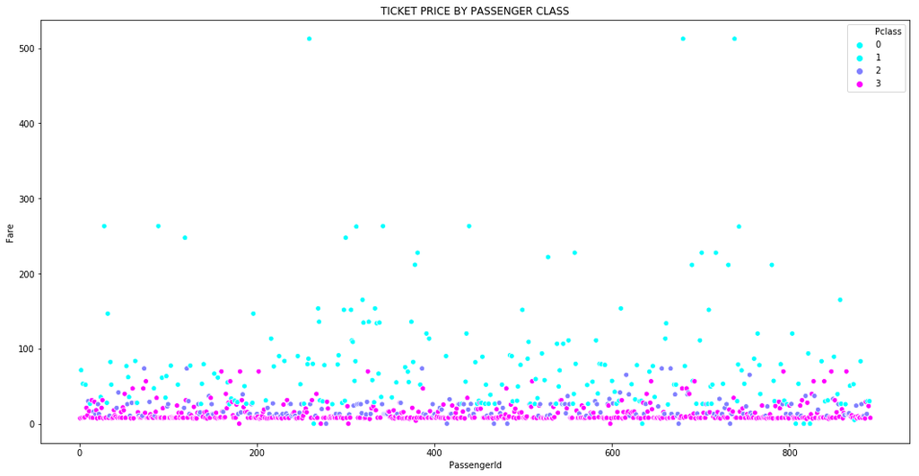

```python
fig = plt.figure( figsize=(18,9))
sns.scatterplot(x='PassengerId', y='Fare', data=titanic, hue='Pclass', palette='cool',)
plt.title('TICKET PRICE BY PASSENGER CLASS')
```

NOTICE THAT THE FIRST CLASS DIVIDE ITSELF INTO TWO CATEGORIES

THA IS WHAT THEY MEAN BY

- First Class (parlor suite) — £870/$4,350 ($50,000 today).
- First Class (berth)— £30/$150 ($1724 today).